# take-home exam

Norman Hong

May 4, 2019

# Part 1 Bikeshare Ridership

## Problem 1

Use numerical summaries, graphs, etc. to answer the following questions. No model fitting or other statistical procedures are required for this. Each graph should help answer one or more of these questions and should be accompanies by explanation.

### (a)

How do rideship counts depend on the year? The month? The hour of the day? How do casual and registered riders differ in this respect?

It looks like total rideship increased in 2012, is slightly higher in the summer, and is higher during rush hour.

```r
cabi$cnt <- cabi$registered + cabi$casual
```

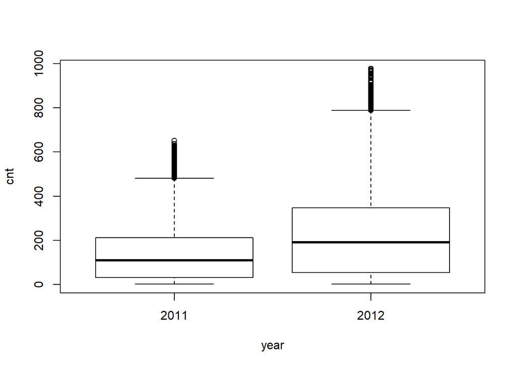

```r
# total rideshsip
boxplot(cnt~year, data=cabi)
```

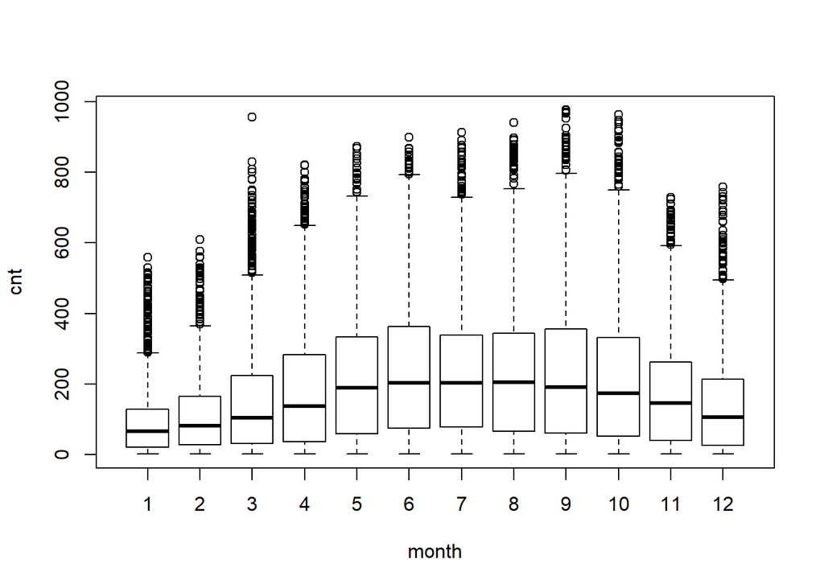

```r
boxplot(cnt~month, data=cabi)
```

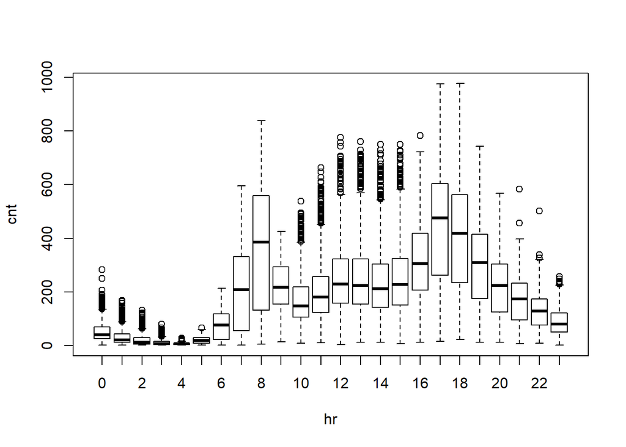

```r
boxplot(cnt~hr, data=cabi)
```

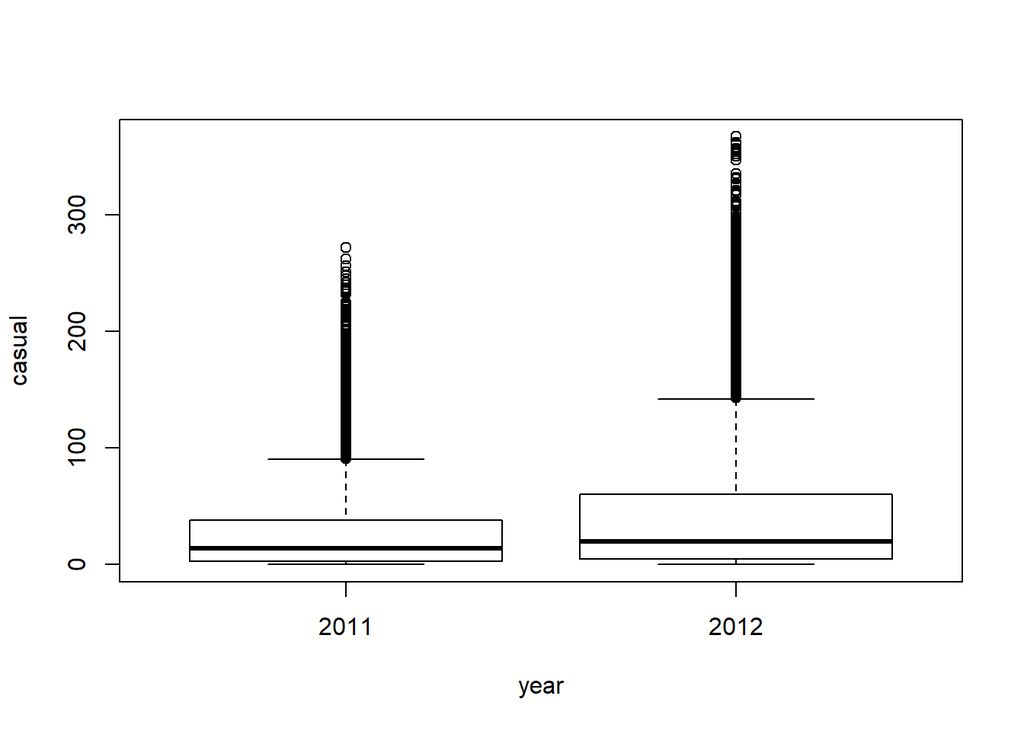

```r
# Casual Riders
boxplot(casual~year, data=cabi)
```

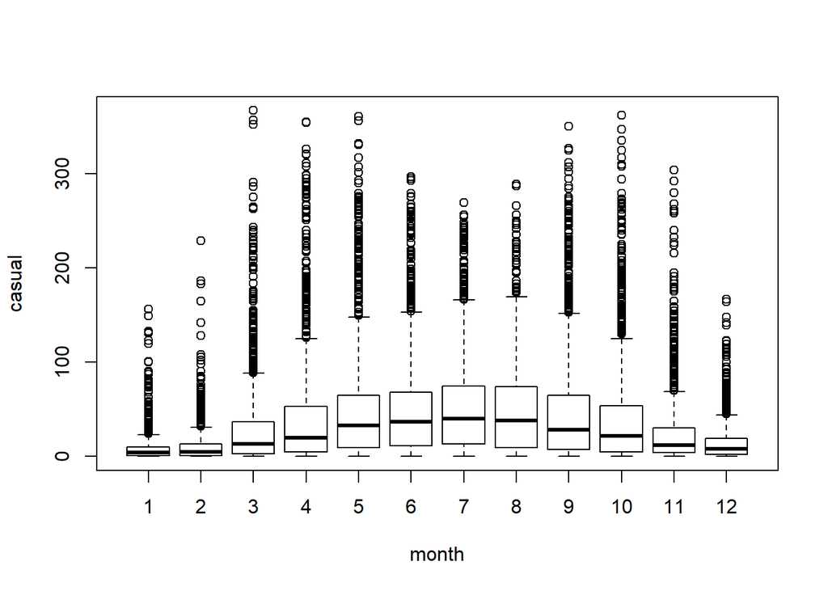

```r
boxplot(casual~month, data=cabi)
```

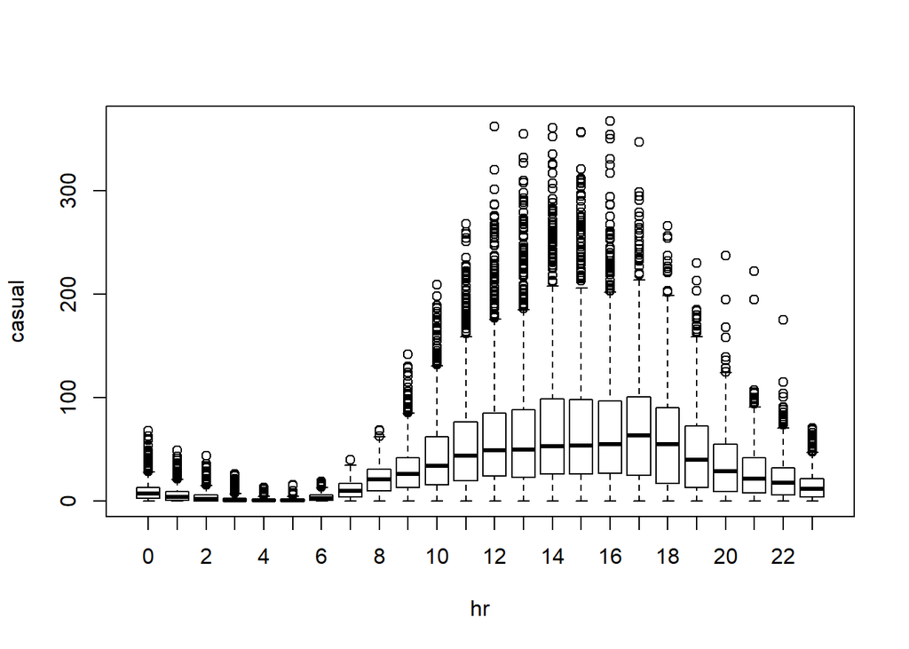

```r
boxplot(casual~hr, data=cabi)
```

Registered riders increased in the year 2012, is slightly higher in the summer time, and peaks during rush hour.

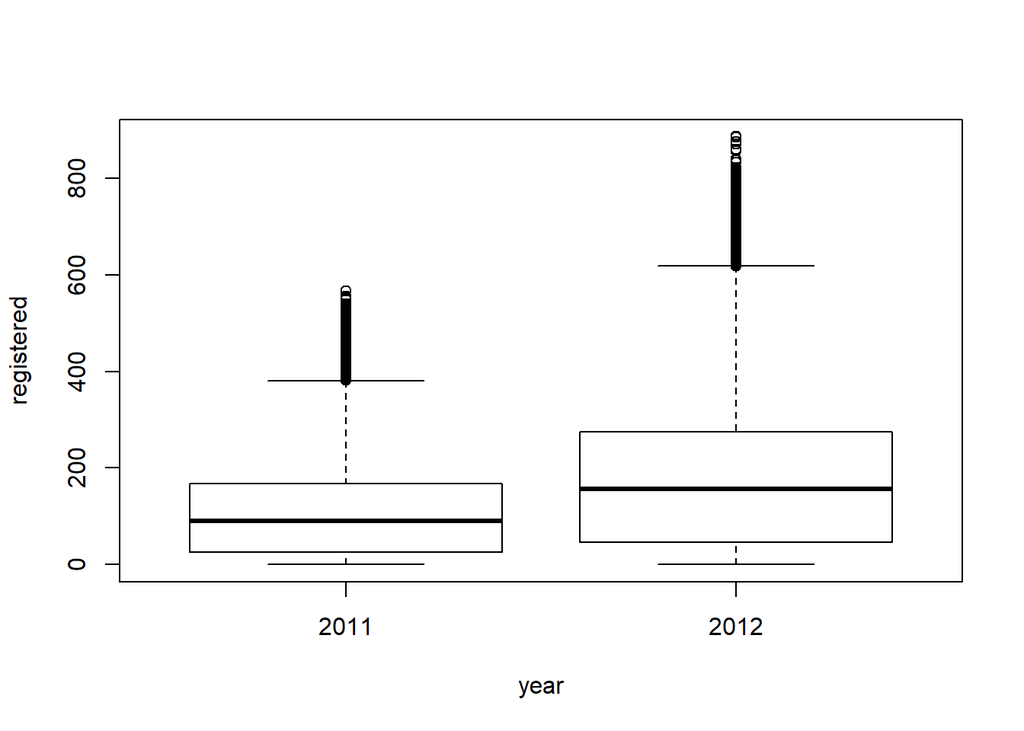

```r
# registered riders
boxplot(registered~year, data=cabi)
```

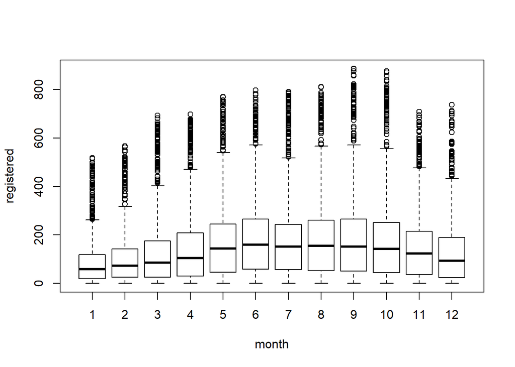

```r
boxplot(registered~month, data=cabi)
```

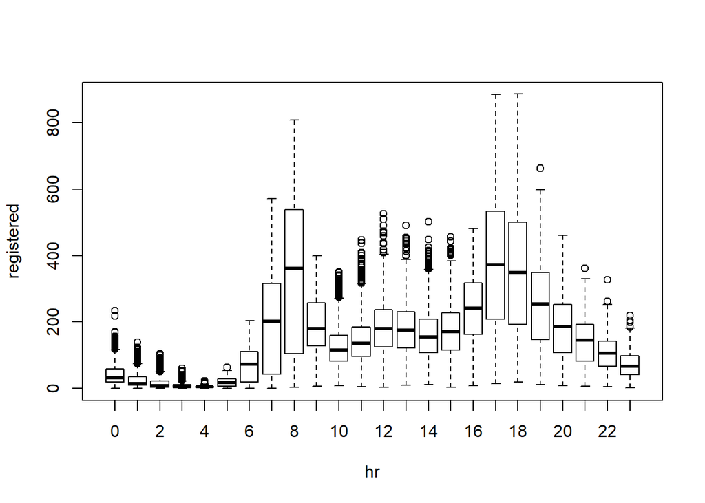

```r
boxplot(registered~hr, data=cabi)
```

### (b)

How are casual and registered rideship counts related? Does this depend on the year? Does it depend on the type of day (working day or not)?

There seems to be no relationshp between registered and casual rideship based on the year.

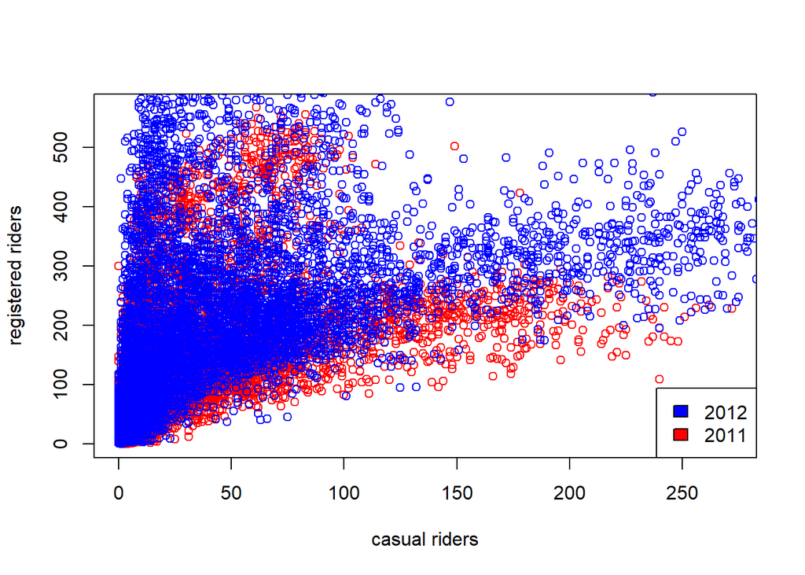

```r
plot(x=cabi$casual[cabi$year == 2011], y=cabi$registered[cabi$year == 2011], col='red', xlab='casual riders', ylab='registered riders')
legend("bottomright", c("2012", "2011"), fill=c("blue","red"))
points(x=cabi$casual[cabi$year == 2012], y=cabi$registered[cabi$year == 2012], col='blue')
```

On a working day, the relationship between registered riders and casual riders is more positive than on a non working day.

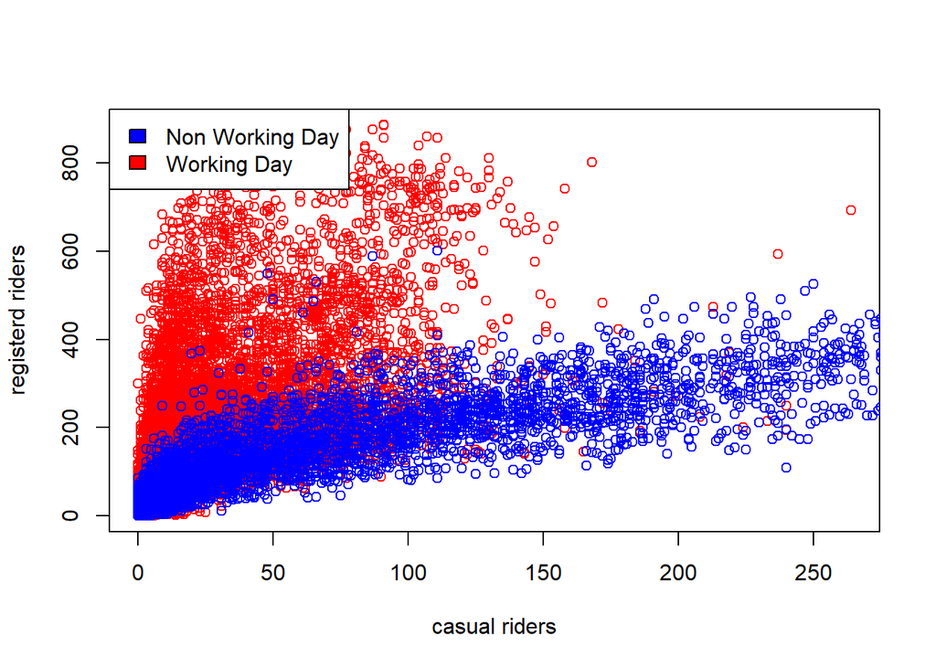

```r
plot(x=cabi$casual[cabi$wday == 1], y=cabi$registered[cabi$wday == 1], col='red', xlab='casual riders', ylab='registerd riders')
legend("topleft", c("Non Working Day", "Working Day"), fill=c("blue","red"))
points(x=cabi$casual[cabi$wday == 0], y=cabi$registered[cabi$wday == 0], col='blue')
```

### (c)

Is there an association between the weather situation and ridership counts? for casual riders? For registered riders?

There is a slight decrease in total ridership when it is cloudy or foggy when compared to sunny. There is a big decrease in total ridership when it is snowing or raining or thundering. This trend extends to both casual riders and registered riders.

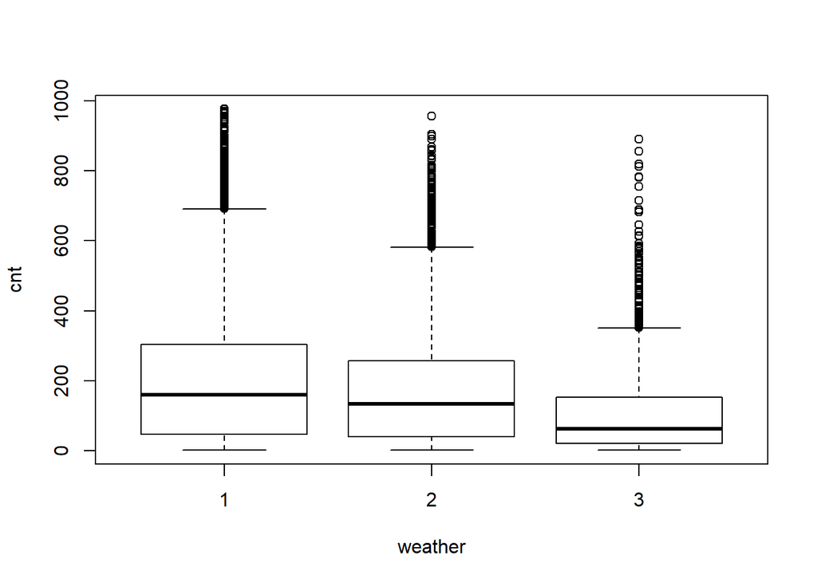

```r
# ridership vs weather
boxplot(cnt~weather, data=cabi)
```

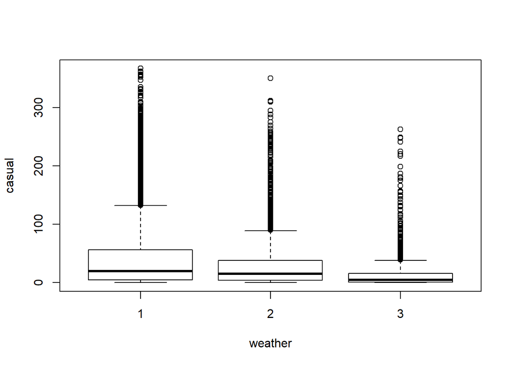

```r
boxplot(casual~weather, data=cabi)
```

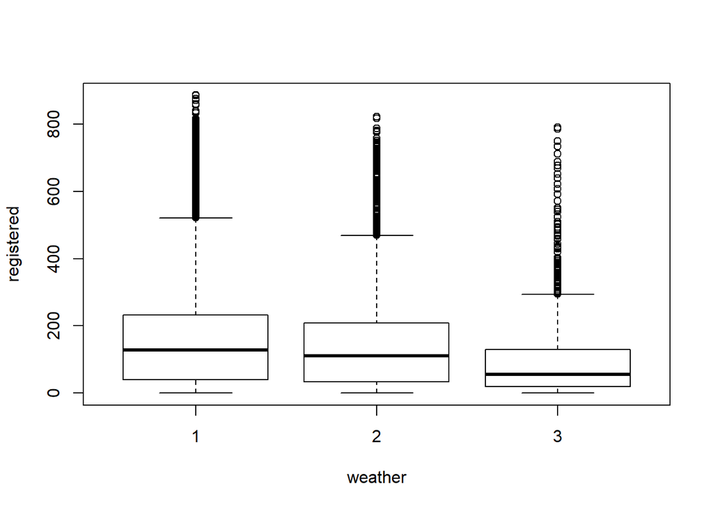

```r
boxplot(registered~weather, data=cabi)
```

### (d)

There are relations between time related predictors and weather related predictors. Demonstrate this with a few suitable graphs.

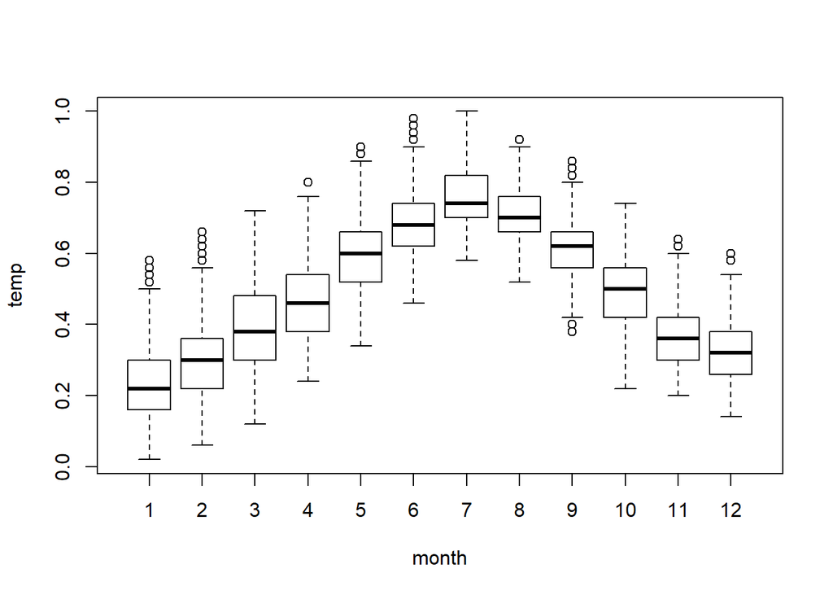

```r
boxplot(temp~month, data=cabi)
```

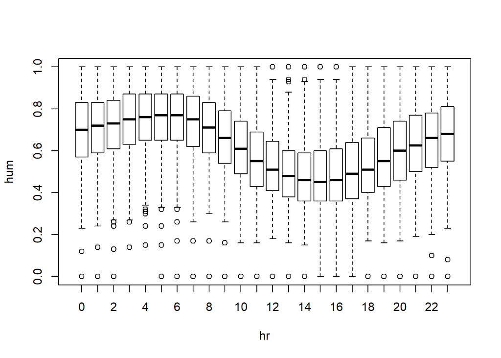

```r
boxplot(hum~hr, data=cabi)
```

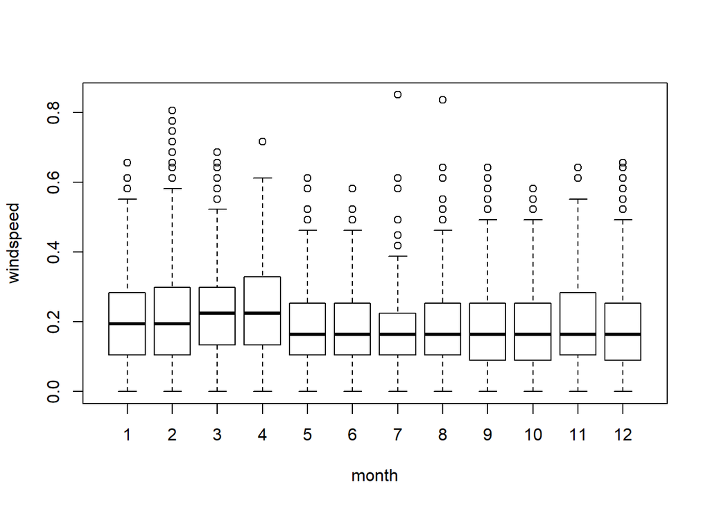

```r
boxplot(windspeed~month, data=cabi)
```

## Problem 2

```r
set.seed(100)
trainIdx <- sample(nrow(cabi), .7*nrow(cabi), replace=FALSE)
train.cabi <- cabi[trainIdx,]
test.cabi <- cabi[-trainIdx,]
```

### (a) Fit a multiple regression to predict registered rideship from the other variables (excluding casual riders), using the training data. Identify the significant variables and comment

The only non significant variables are month2, month9, month10, month12, and weather2.

```r
lm.fit <- lm(registered~season+year+month+wday+hr+temp+atemp+hum+windspeed+weather, data=train.cabi)
summary(lm.fit)
```

```
##
## Call:
## lm(formula = registered ~ season + year + month + wday + hr +
##     temp + atemp + hum + windspeed + weather, data = train.cabi)
##
## Residuals:
##     Min      1Q  Median      3Q     Max
## -280.69  -78.04  -25.31   45.48  617.50
##
## Coefficients:
##               Estimate Std. Error t value Pr(>|t|)
## (Intercept) -1.364e+05  4.497e+03 -30.337  < 2e-16 ***
## season2      3.614e+01  6.962e+00   5.191 2.13e-07 ***
## season3      2.821e+01  8.283e+00   3.406 0.000662 ***
## season4      6.275e+01  7.053e+00   8.896  < 2e-16 ***
## year         6.781e+01  2.235e+00  30.337  < 2e-16 ***
## month2       8.635e-02  5.549e+00   0.016 0.987584
## month3      -1.498e+01  6.256e+00  -2.394 0.016677 *
## month4      -3.243e+01  9.263e+00  -3.501 0.000466 ***
## month5      -3.051e+01  9.881e+00  -3.088 0.002020 **
## month6      -4.611e+01  1.005e+01  -4.588 4.53e-06 ***
## month7      -6.725e+01  1.137e+01  -5.916 3.38e-09 ***
## month8      -4.345e+01  1.114e+01  -3.899 9.70e-05 ***
## month9      -5.466e+00  9.948e+00  -0.549 0.582731
## month10     -1.753e+01  9.256e+00  -1.894 0.058244 .
## month11     -2.399e+01  8.941e+00  -2.684 0.007295 **
## month12     -7.946e+00  7.134e+00  -1.114 0.265376
## wday1        3.940e+01  2.392e+00  16.473  < 2e-16 ***
## hr           6.276e+00  1.730e-01  36.280  < 2e-16 ***
## temp         1.503e+02  4.204e+01   3.575 0.000351 ***
## atemp        1.227e+02  4.401e+01   2.788 0.005318 **
## hum         -1.304e+02  7.325e+00 -17.803  < 2e-16 ***
## windspeed    3.454e+01  1.011e+01   3.417 0.000634 ***
## weather2     4.079e+00  2.711e+00   1.504 0.132524
## weather3    -3.103e+01  4.596e+00  -6.752 1.52e-11 ***
## ---
## Signif. codes:  0 '***' 0.001 '**' 0.01 '*' 0.05 '.' 0.1 ' ' 1
##
## Residual standard error: 122 on 12141 degrees of freedom
## Multiple R-squared:  0.3495, Adjusted R-squared:  0.3483
## F-statistic: 283.6 on 23 and 12141 DF,  p-value: < 2.2e-16
```

### (b)

Estimate the RMS prediction error of this model using the test set.

```r
pred <- predict(lm.fit, newdata=test.cabi)
error <- pred - test.cabi$registered
rmse <- sqrt(mean(error^2))
rmse
```

```
## [1] 123.1998
```

### (c)

Does the RMS prediction error depend on the month? Answer this question using the test data and suitable tables or graphs.

The RMSE increases as we go from January to August. After August, the RMSE starts to decrease monotonically.

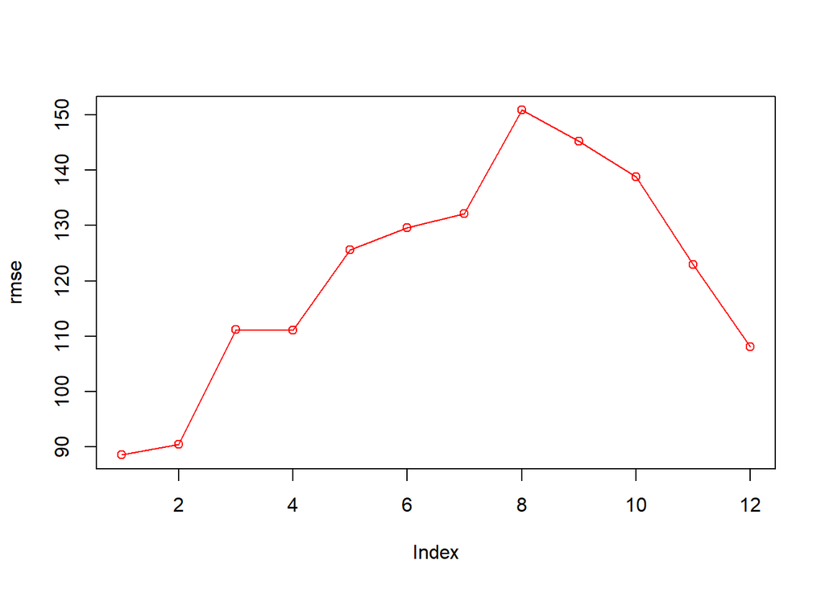

```r
months <- seq(1,12,1)
rmse <- rep(0,12)
c <- 1
for (month in months)
{
  temp <- test.cabi[test.cabi$month==month,]
  pred <- predict(lm.fit, newdata=temp)
  RMSE <- sqrt(mean((pred - temp$registered)^2))
  rmse[c] <- RMSE
  c <- c + 1
}
plot(rmse,type="o",col='red')
```

### (d)

Make copies of the training and test data in which hr is a categorical variable. Fit a multiple regression model. Compare the summary of this model to the one from part (a). Also estimate the RMS prediction error from the test set.

```r
train.cabi1 <- train.cabi
train.cabi1$hr <- as.factor(train.cabi1$hr)

test.cabi1 <- test.cabi
test.cabi1$hr <- as.factor(test.cabi1$hr)
```

```r
lm.fit1 <- lm(registered~season+year+month+wday+hr+temp+atemp+hum+windspeed+weather, data=train.cabi1)
summary(lm.fit1)
```

```
##
## Call:
## lm(formula = registered ~ season + year + month + wday + hr +
##     temp + atemp + hum + windspeed + weather, data = train.cabi1)
##
## Residuals:
##     Min      1Q  Median      3Q     Max
## -329.77  -48.45   -6.87   45.13  421.52
##
## Coefficients:
##               Estimate Std. Error t value Pr(>|t|)
## (Intercept) -1.434e+05  3.156e+03 -45.442  < 2e-16 ***
## season2      3.563e+01  4.868e+00   7.319 2.65e-13 ***
## season3      3.642e+01  5.793e+00   6.287 3.35e-10 ***
## season4      6.477e+01  4.931e+00  13.136  < 2e-16 ***
## year         7.128e+01  1.569e+00  45.431  < 2e-16 ***
## month2       6.208e+00  3.888e+00   1.597 0.110364
## month3       2.237e+00  4.416e+00   0.507 0.612426
## month4      -5.991e+00  6.547e+00  -0.915 0.360177
## month5       3.029e+00  7.003e+00   0.432 0.665388
## month6       4.502e-01  7.196e+00   0.063 0.950114
## month7      -2.022e+01  8.101e+00  -2.495 0.012592 *
## month8      -5.351e+00  7.904e+00  -0.677 0.498470
## month9       1.968e+01  7.016e+00   2.805 0.005044 **
## month10      5.493e-01  6.499e+00   0.085 0.932649
## month11     -1.521e+01  6.258e+00  -2.430 0.015126 *
## month12     -8.921e+00  4.989e+00  -1.788 0.073761 .
## wday1        4.199e+01  1.673e+00  25.105  < 2e-16 ***
## hr1         -1.331e+01  5.308e+00  -2.508 0.012160 *
## hr2         -1.873e+01  5.373e+00  -3.486 0.000493 ***
## hr3         -3.021e+01  5.420e+00  -5.574 2.55e-08 ***
## hr4         -3.241e+01  5.447e+00  -5.950 2.75e-09 ***
## hr5         -1.910e+01  5.357e+00  -3.566 0.000363 ***
## hr6          3.873e+01  5.333e+00   7.263 4.03e-13 ***
## hr7          1.587e+02  5.346e+00  29.685  < 2e-16 ***
## hr8          2.988e+02  5.351e+00  55.838  < 2e-16 ***
## hr9          1.445e+02  5.335e+00  27.077  < 2e-16 ***
## hr10         7.737e+01  5.383e+00  14.372  < 2e-16 ***
## hr11         9.279e+01  5.463e+00  16.987  < 2e-16 ***
## hr12         1.269e+02  5.496e+00  23.094  < 2e-16 ***
```

[output cut: 8 more lines]

```
## hr21         9.505e+01  5.365e+00  17.715  < 2e-16 ***
## hr22         6.437e+01  5.359e+00  12.011  < 2e-16 ***
## hr23         3.011e+01  5.324e+00   5.656 1.59e-08 ***
## temp         4.117e+01  2.963e+01   1.389 0.164773
## atemp        1.162e+02  3.078e+01   3.774 0.000162 ***
## hum         -5.449e+01  5.561e+00  -9.798  < 2e-16 ***
## windspeed   -1.031e+01  7.093e+00  -1.453 0.146126
## weather2    -6.671e+00  1.919e+00  -3.476 0.000511 ***
## weather3    -5.468e+01  3.271e+00 -16.715  < 2e-16 ***
## ---
## Signif. codes:  0 '***' 0.001 '**' 0.01 '*' 0.05 '.' 0.1 ' ' 1
##
## Residual standard error: 85.3 on 12119 degrees of freedom
## Multiple R-squared:  0.6828, Adjusted R-squared:  0.6816
## F-statistic: 579.8 on 45 and 12119 DF,  p-value: < 2.2e-16
```

```r
pred <- predict(lm.fit1, newdata=test.cabi1)
error <- pred - test.cabi1$registered
rms <- sqrt(mean(error^2))
rms
```

```
## [1] 86.21328
```

## Problem 3

Use the original cabi data for this problem.

### (a)

Train artificial neural networks with various numbers of nodes in the hidden layer to predict registered ridership. Use the training data and only weather related variables. Recommend a suitable number of nodes, with explanation.

```r
set.seed(100)
nn1 <- nnet(registered~temp+atemp+hum+windspeed+weather, data=train.cabi, size=100, maxit=100, decay=0, linout=TRUE, trace=F)
# Training error.
cat('Training RMSE:', sqrt(mean(residuals(nn1)^2)))
```

```
## Training RMSE: 133.7815
```

```r
# Test error
pred <- predict(nn1, newdata=test.cabi, type='raw')
error <- pred - test.cabi$registered
cat('\n Test RMSE:', sqrt(mean(error**2)))
```

```
##
##  Test RMSE: 134.5758
```

```r
set.seed(100)
nn1 <- nnet(registered~temp+atemp+hum+windspeed+weather, data=train.cabi, size=20, maxit=100, decay=.01, linout=TRUE, trace=F)
# Training error.
cat('Training RMSE:', sqrt(mean(residuals(nn1)^2)))
```

```
## Training RMSE: 134.3063
```

```r
# Test error
pred <- predict(nn1, newdata=test.cabi, type='raw')
error <- pred - test.cabi$registered
cat('\nTest RMSE:', sqrt(mean(error**2)))
```

```
##
## Test RMSE: 135.1253
```

```r
set.seed(100)
nn1 <- nnet(registered~temp+atemp+hum+windspeed+weather, data=train.cabi, size=3, maxit=100, decay=.01, linout=TRUE, trace=F)
# Training error.
cat('Training RMSE:', sqrt(mean(residuals(nn1)^2)))
```

```
## Training RMSE: 135.1368
```

```r
# Test error
pred <- predict(nn1, newdata=test.cabi, type='raw')
error <- pred - test.cabi$registered
cat('\nTest RMSE:', sqrt(mean(error**2)))
```

```
##
## Test RMSE: 135.4755
```

```r
set.seed(100)
nn1 <- nnet(registered~temp+atemp+hum+windspeed+weather, data=train.cabi, size=2, maxit=100, decay=.01, linout=TRUE, trace=F)
# Training error.
cat('Training RMSE:', sqrt(mean(residuals(nn1)^2)))
```

```
## Training RMSE: 135.8845
```

```r
# Test error
pred <- predict(nn1, newdata=test.cabi, type='raw')
error <- pred - test.cabi$registered
cat('\nTest RMSE:', sqrt(mean(error**2)))
```

```
##
## Test RMSE: 136.3472
```

### (b)

Repeat part (a), using only time related variables.

```r
set.seed(100)
nn1 <- nnet(registered~season+year+month+wday+hr, data=train.cabi, size=1, maxit=100, decay=.01, linout=T, trace=F)
# Training error
cat('Training RMSE:', sqrt(mean(residuals(nn1)^2)))
```

```
## Training RMSE: 151.1684
```

```r
# Test error
pred <- predict(nn1, newdata=test.cabi, type='raw')
error <- pred - test.cabi$registered
cat('\nTest RMSE:', sqrt(mean(error**2)))
```

```
##
## Test RMSE: 151.7856
```

```r
set.seed(100)
nn1 <- nnet(registered~season+year+month+wday+hr, data=train.cabi, size=5, maxit=100, decay=.01, linout=T, trace=F)

# Training error
cat('Training RMSE:', sqrt(mean(residuals(nn1)^2)))
```

```
## Training RMSE: 151.1684
```

```r
# Test error
pred <- predict(nn1, newdata=test.cabi, type='raw')
error <- pred - test.cabi$registered
cat('\nTest RMSE:', sqrt(mean(error**2)))
```

```
##
## Test RMSE: 151.7856
```

```r
set.seed(100)
nn1 <- nnet(registered~season+year+month+wday+hr, data=train.cabi, size=10, maxit=100, decay=.01, linout=T, trace=F)

# Training error
cat('Training RMSE:', sqrt(mean(residuals(nn1)^2)))
```

```
## Training RMSE: 151.1684
```

```r
# Test error
pred <- predict(nn1, newdata=test.cabi)
error <- pred - test.cabi$registered
cat('\nTest RMSE:', sqrt(mean(error**2)))
```

```
##
## Test RMSE: 151.7856
```

```r
set.seed(100)
nn1 <- nnet(registered~season+year+month+wday+hr, data=train.cabi, size=20, maxit=100, decay=.01, linout=T, trace=F)

# Training error
cat('Training RMSE:', sqrt(mean(residuals(nn1)^2)))
```

```
## Training RMSE: 151.1684
```

```r
# Test error
pred <- predict(nn1, newdata=test.cabi)
error <- pred - test.cabi$registered
cat('\nTest RMSE:', sqrt(mean(error**2)))
```

```
##
## Test RMSE: 151.7856
```

```r
set.seed(100)
nn1 <- nnet(registered~season+year+month+wday+hr, data=train.cabi, size=50, maxit=100, decay=.01, linout=T, trace=F)

# Training error
cat('Training RMSE:', sqrt(mean(residuals(nn1)^2)))
```

```
## Training RMSE: 151.1684
```

```r
# Test error
pred <- predict(nn1, newdata=test.cabi)
error <- pred - test.cabi$registered
cat('\nTest RMSE:', sqrt(mean(error**2)))
```

```
##
## Test RMSE: 151.7856
```

### (c)

Repeat part (a) using two time related and 2 weather related variables. Explain your choice of variables.

```r
set.seed(100)
nn1 <- nnet(registered~temp+weather+wday+hr, data=train.cabi, size=50, maxit=500, decay=.01, linout=T, trace=F)

# Training error
cat('Training RMSE:', sqrt(mean(residuals(nn1)^2)))
```

```
## Training RMSE: 104.6087
```

```r
# Test error
pred <- predict(nn1, newdata=test.cabi)
error <- pred - test.cabi$registered
cat('\nTest RMSE:', sqrt(mean(error**2)))
```

```
##
## Test RMSE: 105.5428
```

```r
set.seed(100)
nn1 <- nnet(registered~temp+weather+wday+hr, data=train.cabi, size=100, maxit=500, decay=.01, linout=T, trace=F)

# Training error
cat('Training RMSE:', sqrt(mean(residuals(nn1)^2)))
```

```
## Training RMSE: 68.20347
```

```r
# Test error
pred <- predict(nn1, newdata=test.cabi)
error <- pred - test.cabi$registered
cat('\nTest RMSE:', sqrt(mean(error**2)))
```

```
##
## Test RMSE: 70.76593
```

```r
set.seed(100)
nn1 <- nnet(registered~temp+weather+wday+hr, data=train.cabi, size=70, maxit=500, decay=.01, linout=T, trace=F)

# Training error
cat('Training RMSE:', sqrt(mean(residuals(nn1)^2)))
```

```
## Training RMSE: 66.51604
```

```r
# Test error
pred <- predict(nn1, newdata=test.cabi)
error <- pred - test.cabi$registered
cat('\nTest RMSE:', sqrt(mean(error**2)))
```

```
##
## Test RMSE: 68.91109
```

```r
set.seed(100)
nn1 <- nnet(registered~temp+weather+wday+hr, data=train.cabi, size=60, maxit=500, decay=.01, linout=T, trace=F)

# Training error
cat('Training RMSE:', sqrt(mean(residuals(nn1)^2)))
```

```
## Training RMSE: 90.30851
```

```r
# Test error
pred <- predict(nn1, newdata=test.cabi)
error <- pred - test.cabi$registered
cat('\nTest RMSE:', sqrt(mean(error**2)))
```

```
##
## Test RMSE: 92.59509
```